# Lab 4

# 7

```r
met_avg2 <- met_avg[!is.na(rh)]

top10 <- met_avg2[rank(-rh) <= 10]

rh_pal = colorNumeric(c('blue','purple','red'), domain = met_avg2$rh)

leaflet(met_avg2) %>%
  addProviderTiles('OpenStreetMap') %>%
  addCircles(lat=~lat, lng=~lon, color=~rh_pal(rh),
             label=~paste0(round(rh,2), ' rh'), opacity=1,fillOpacity = 1, radius = 500) %>%
  addMarkers(lat=~lat, lng=~lon, label=~paste0(round(rh,2), ' rh'), data = top10) %>%
  addLegend('bottomleft',pal=rh_pal, values=met_avg2$rh,
            title="Relative Humidity", opacity = 1)
```

[interactive chart not shown]

**The relative humidity map reveals a clear, gradual increase gradient across the United States. The eastern regions show higher humidity values, represented by purple and red colors. The central region displays a mid-range humidity levels, while the western regions exhibit low humidity values, with the exception of the western costal region. Majority of the top 10 highest relative humidity locations are predominantly located near bodies of water, which reflects the influence of moisture deriving from the ocean. This pattern demonstrates how wind speed and dew point factors affect regional humidity distributions.**

# 8

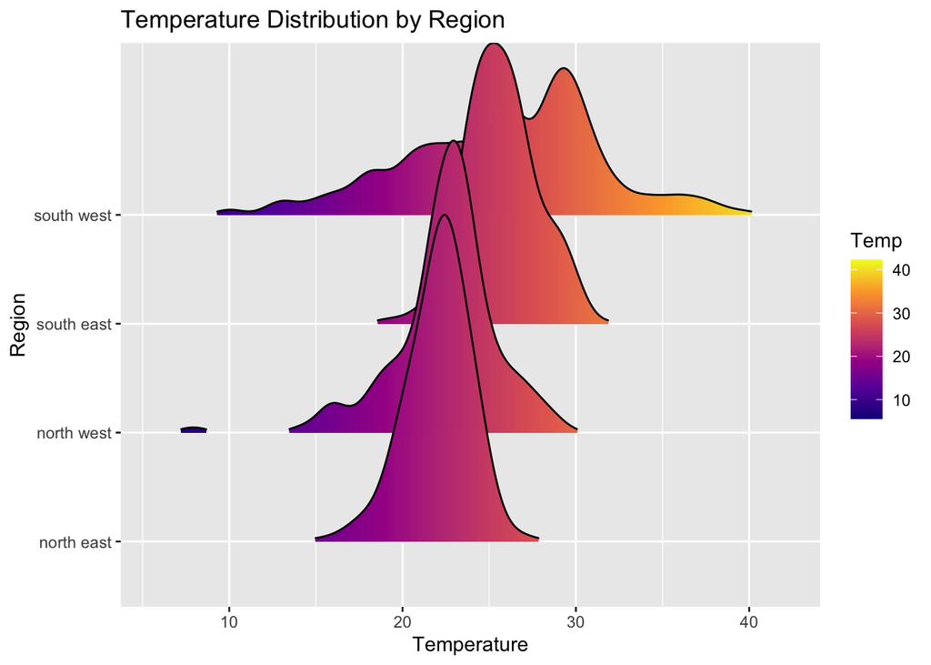

```r
library(ggridges)

ggplot(met_avg, aes(x = temp, y = region, fill = stat(x))) +
  geom_density_ridges_gradient(scale = 3, rel_min_height = 0.01) +
  scale_fill_viridis_c(name = "Temp", option = "C") +
  labs(title = 'Temperature Distribution by Region',
       x = "Temperature",
       y = "Region")
```